# The Kruskal-Wallis test, derived from first principles

Deriving the Kruskal-Wallis test from scratch, using a pain management trial to show where ANOVA falls short.

26 April 2026

Let’s say that we want to test the effects of pain management protocols. We have 45 post-surgical patients randomized to three groups: opioid-only, NSAID + nerve block and multimodal. 48 hours after their operations, each patient marks their pain on a 0-10 visual analog scale (VAS). The question that the clinic is interested in is whether the three different protocols produce different pain levels or not.

ANOVA [1] is a popular test for testing whether group means are equal. The problem with ANOVA in the pain scale example is that the pain scores are typically right-skewed (clustering around 2-4) and with small sample sizes, the within-group variance can be inflated by some observations being at the right tail (8-10). ANOVA computes an F-statistic as a ratio of between-group variance to within-group variance. If the within group variance is inflated, ANOVA needs a larger between-group variance to detect a difference.

**Notation used in this post**

| Symbol | Meaning |
| --- | --- |
| $K$ | Number of groups |
| $j$ | Group index, $j \in \{1, \ldots, K\}$ |
| $n_j$ | Number of observations in group $j$ |
| $N$ | Total sample size $N = \sum_j n_j$ |
| $x_{ij}$ | The $i$-th observation in group $j$ |
| $R_{ij}$ | Rank of $x_{ij}$ among all $N$ pooled observations |
| $R_j$ | Rank sum of group $j$: $R_j = \sum_i R_{ij}$ |
| $\bar{R}_j$ | Mean rank of group $j$: $\bar{R}_j = R_j / n_j$ |
| $\bar{R}$ | Grand mean rank: $\bar{R} = (N+1)/2$ |
| $H$ | Kruskal-Wallis test statistic |
| $F$ | ANOVA F-statistic |
| $\chi^2(K-1)$ | Chi-square distribution with $K-1$ degrees of freedom |

## The pain trial

**Pain trial data**

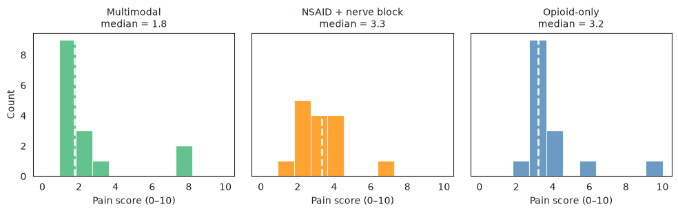

[figure not shown]

Figure 1: VAS pain scores at 48 h post-surgery for three protocols. Dashed line shows the group median.

Table 1: Summary statistics for the three pain management protocols.

| Protocol | n | Mean | Median | SD |
| --- | --- | --- | --- | --- |
| Multimodal | 15 | 2.57 | 1.8 | 2.21 |
| NSAID + nerve block | 15 | 3.21 | 3.3 | 1.37 |
| Opioid-only | 15 | 3.93 | 3.2 | 1.92 |

```python
import numpy as np
import matplotlib.pyplot as plt
from scipy import stats

# VAS pain scores at 48 h post-op (0 = no pain, 10 = worst imaginable)
# Gamma(shape=0.5) → heavy right skew; offset shifts group medians apart
rng = np.random.default_rng(99)
pain_a = np.clip(np.round(rng.gamma(0.5, 3.0, 15) + 1.0, 2), 0, 10)  # multimodal:          mean ≈ 2.6
pain_b = np.clip(np.round(rng.gamma(0.5, 3.0, 15) + 1.8, 2), 0, 10)  # NSAID + nerve block: mean ≈ 3.4
pain_c = np.clip(np.round(rng.gamma(0.5, 3.0, 15) + 2.6, 2), 0, 10)  # opioid-only:         mean ≈ 3.9

labels = ["Multimodal", "NSAID + nerve block", "Opioid-only"]
colors = ["mediumseagreen", "darkorange", "steelblue"]
groups = [pain_a, pain_b, pain_c]

plt.rcParams.update(
    {
        "text.color": "white",
        "axes.labelcolor": "white",
        "xtick.color": "white",
        "ytick.color": "white",
        "axes.edgecolor": "white",
    }
)

fig, axes = plt.subplots(1, 3, figsize=(10, 3.2), sharey=True, sharex=True)
fig.patch.set_alpha(0)

for ax, g, color, label in zip(axes, groups, colors, labels):
    ax.hist(
        g,
        bins=np.linspace(0, 10, 12),
        color=color,
        alpha=0.8,
        edgecolor="white",
        linewidth=0.8,
    )
    ax.axvline(np.median(g), color="white", linewidth=2, linestyle="--", alpha=0.9)
    ax.set_title(f"{label}\nmedian = {np.median(g):.1f}", fontsize=10, color="white")
    ax.set_xlabel("Pain score (0–10)")
    ax.set_xlim(-0.5, 10.5)
    ax.patch.set_alpha(0)

axes[0].set_ylabel("Count")
plt.tight_layout()
plt.show()
```

## Deriving the $H$ statistic

### Setting up the problem

The goal is to test whether the groups share the same distribution with each other. Transforming this into a null hypothesis becomes

$$H_0: \text{the ranks } 1, 2, \ldots, N \text{ are randomly distributed across groups}$$

So the next question to answer is: what does a large deviation from the random distribution look like and how can we measure the deviation?

### Expected rank mean under $H_0$

Under $H_0$, every rank is equally likely to fall into any group. Then the expected value of a single rank $R$ drawn from the uniform set $\{1, \ldots, N\}$ is

$$\mathbb{E}[R] = \frac{1}{N} \sum_{r=1}^{N} r = \frac{1}{N}\frac{N(N+1)}{2} = \frac{N+1}{2}$$
(1)

The expected mean rank in all groups is $\bar{R} = \frac{N+1}{2}$, regardless of the individual group sizes. The only thing that matters is the total sample size. If $H_0$ is true, all groups’ mean ranks should hover around $\bar{R}$.

### Building the test statistic

A natural way to measure deviation from the null is the squared distance of each group’s mean rank $\bar{R}_j$ from the expected grand mean:

$$T = \sum_{j=1}^{K} n_j \left(\bar{R}_j - \frac{N+1}{2}\right)^2$$
(2)

Here $n_j$ is the size of group $j$ to weight the penalty of bigger groups more because we have more information of them. This structure is similar to ANOVA’s between-group sum of squares, the sum of squared deviations of each group mean from the global mean:

$$SS_{\text{between}} = \sum_{j=1}^{K} n_j \left(\bar{x}_j - \bar{x}\right)^2$$

### The $12/N(N+1)$ scaling factor

To turn $T$ from Equation 2 into a statistic with a known null distribution, we need to normalize it by the variance of the ranks. With Equation 1, the variance for a discrete uniform distribution on $\{1, \dots, N\}$ is:

$$\begin{align*}
\text{Var}(R) = \sigma^2_R &= \mathbb{E}[R^2] - \left(\mathbb{E}[R]\right)^2 \\
&= \frac{1}{N}\sum_{r=1}^{N} r^2 - \left(\frac{N+1}{2}\right)^2 \\
&= \frac{(N+1)(2N+1)}{6} - \frac{(N+1)^2}{4} \\
&= (N+1)\left[\frac{2(2N+1)}{12} - \frac{3(N+1)}{12}\right] \\
&= (N+1) \cdot \frac{4N+2 - 3N-3}{12} \\
&= \frac{(N+1)(N-1)}{12} \\
&= \frac{N^2-1}{12}
\end{align*}$$

By analogy with the ANOVA F-statistic, we normalise $T$ by $SS_{\text{total}}/(N-1)$, where the total rank sum-of-squares for the complete set of ranks $\{1,\dots,N\}$ is $SS_{\text{total}} = N\sigma^2_R = \frac{N(N^2-1)}{12}$:

$$H = (N-1)\cdot\frac{T}{SS_{\text{total}}} = \frac{12}{N(N+1)} \sum_{j=1}^{K} n_j \left(\bar{R}_j - \frac{N+1}{2}\right)^2$$

The factor $12/[N(N+1)]$ scales $H$ so that its expected value under $H_0$ equals $K-1$, which is exactly the degrees-of-freedom parameter of a chi-square distribution. For large $N$, $H \xrightarrow{d} \chi^2(K-1)$ under $H_0$.

## Back to the pain trial

Now that we’ve shown the mathematical difference between ANOVA and the Kruskal-Wallis test, we can compute the p-values using both of the tests and compare them.

```python
import numpy as np
from scipy import stats

N = sum(len(g) for g in groups)
K = len(groups)

all_scores = np.concatenate(groups)
ranks = stats.rankdata(all_scores)

idx = 0
rank_groups = []
for g in groups:
    rank_groups.append(ranks[idx : idx + len(g)])
    idx += len(g)

grand_mean_rank = (N + 1) / 2
H, p_kw = stats.kruskal(*groups)
F, p_anova = stats.f_oneway(*groups)
```

Grand mean rank (null expectation): 23.0

| Protocol | Rank sum | Mean rank | Deviation |
| --- | --- | --- | --- |
| Multimodal | 212 | 14.17 | -8.83 |
| NSAID + nerve block | 378 | 25.20 | +2.20 |
| Opioid-only | 444 | 29.63 | +6.63 |

| Test | Statistic | df | p-value |
| --- | --- | --- | --- |
| Kruskal-Wallis | H = 11.034 | 2 | 0.0040 |
| ANOVA | F = 1.976 | 2 | 0.1513 |

The multimodal group’s mean rank is well below 23.0 (the grand mean rank), the opioid-only group’s mean rank is well above it. The NSAID + nerve block is quite close to the mean rank. The $H$-statistic is able to quantify the spread. The chi-square p-value tells us whether a deviation this large would occur by chance under the null. With $p < 0.05$, we reject. The KW-test rejects the null, ANOVA doesn’t. In this sample, with heavily skewed distributions, the KW-test detects a difference that ANOVA misses.

What KW doesn’t tell

A statistically significant KW result only says that something differs, not which pairs differ. To investigate which pairs differ, the Dunn test [2] fits this problem well.

## References

[1] Wikipedia contributors, “Analysis of variance,” 2025. [Online]. Available: https://en.wikipedia.org/wiki/Analysis_of_variance. Accessed: 2026-04-25.

[2] Z. Bobbitt, “Dunn's Test for Multiple Comparisons,” 2020. [Online]. Available: https://www.statology.org/dunns-test/. Accessed: 2026-04-25.